# STAT 435 HW1

#### (c)

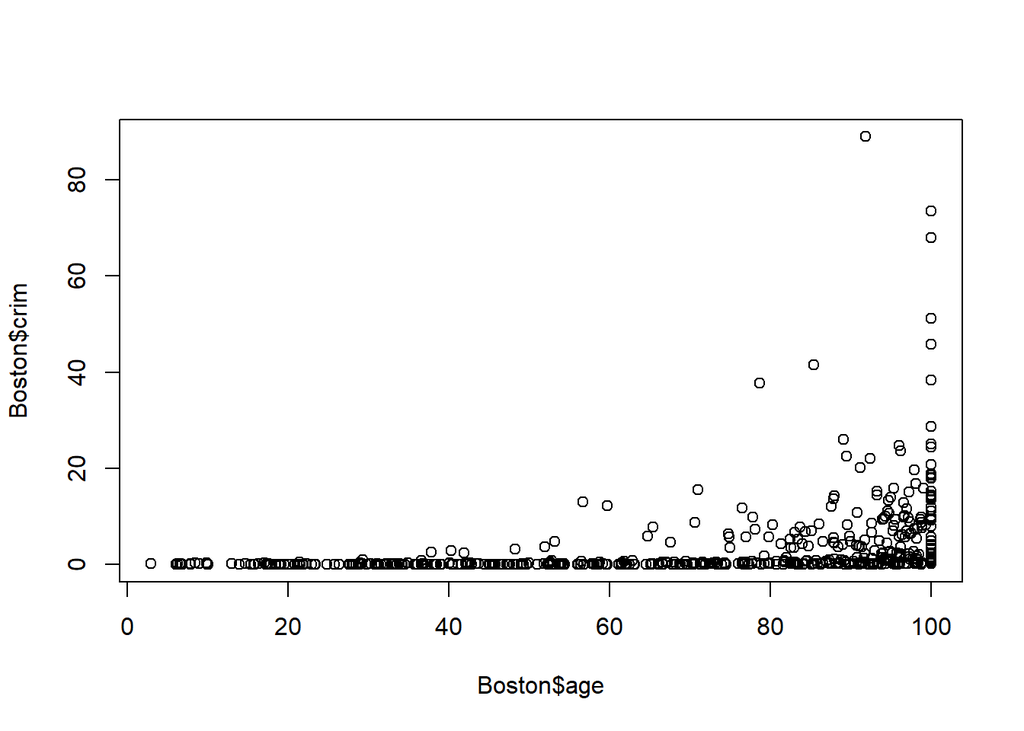

```r
plot(Boston$age, Boston$crim)
```

The older the unit, the higher rate of crime

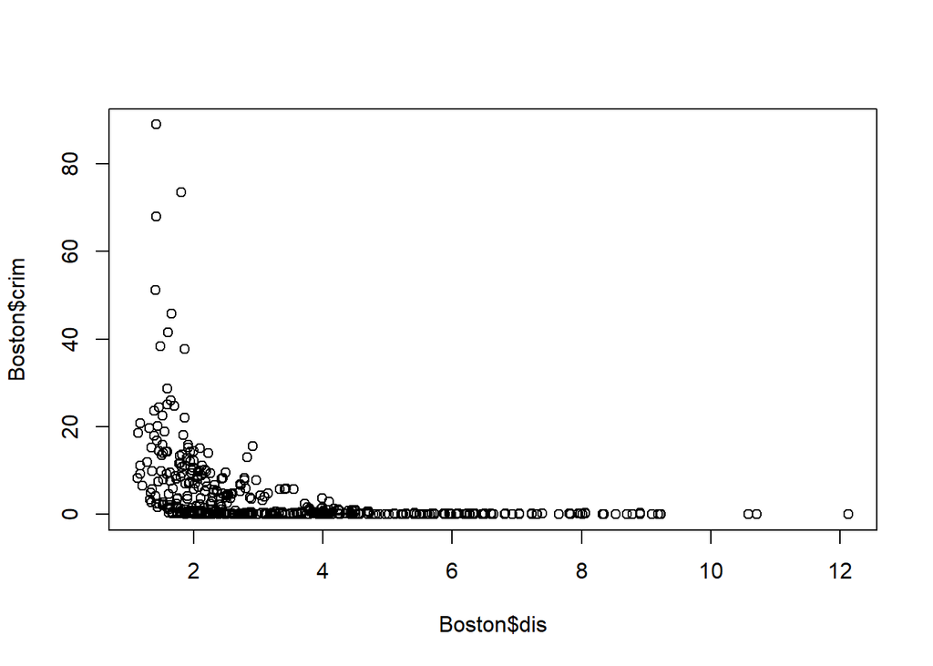

```r
plot(Boston$dis, Boston$crim)
```

The closer to the employment centres, the higher rate of crime

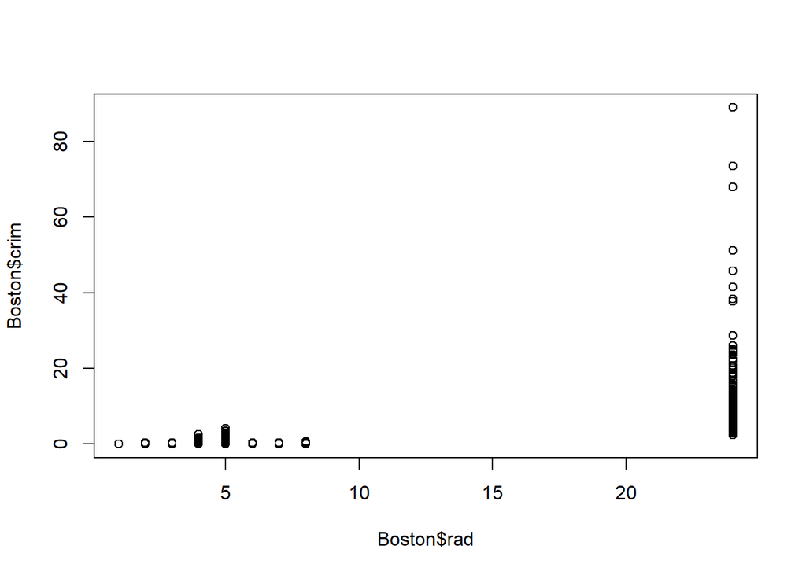

```r
plot(Boston$rad, Boston$crim)
```

The higher index of accessibility to radial highways, the higher rate of crime

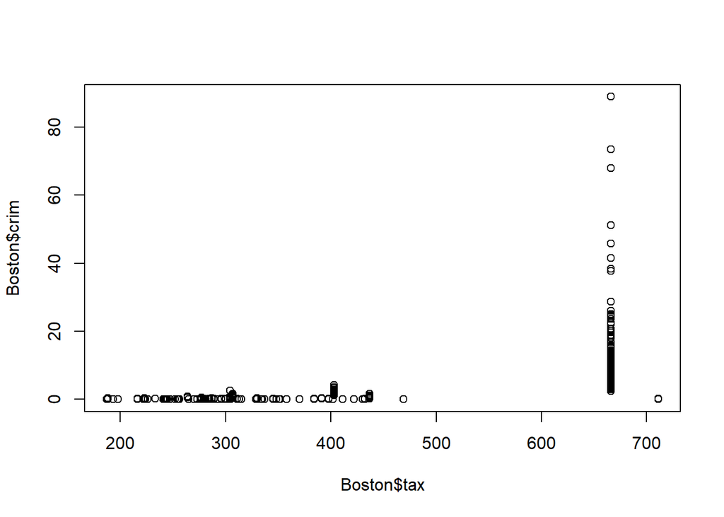

```r
plot(Boston$tax, Boston$crim)
```

The higher tax rate, the higher rate of crime

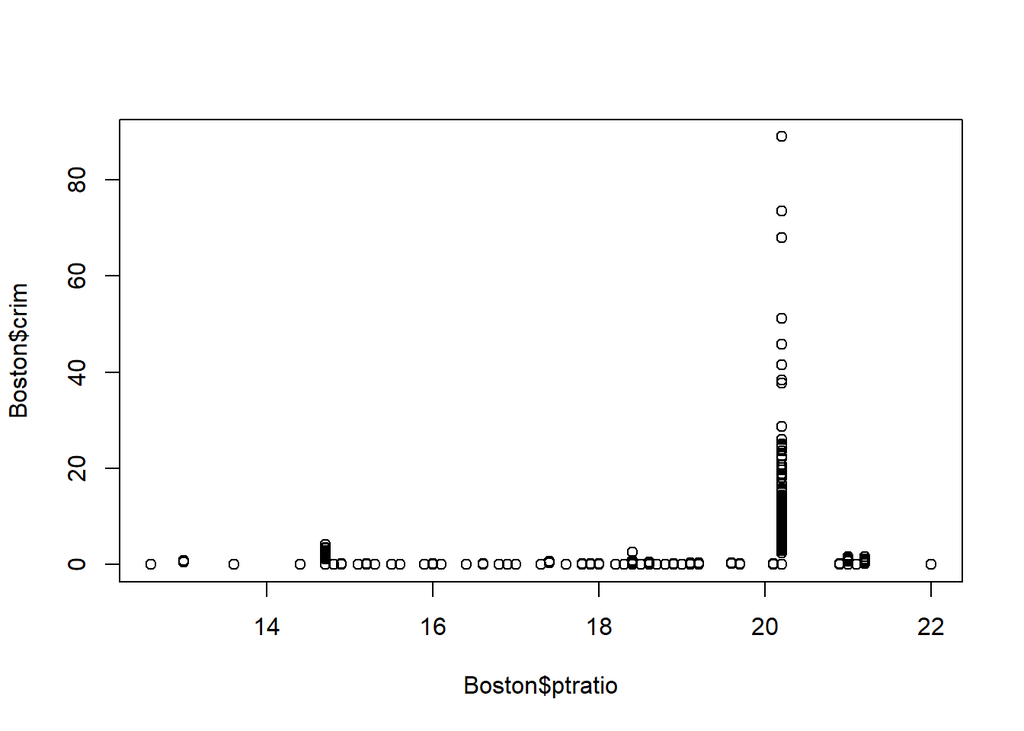

```r
plot(Boston$ptratio, Boston$crim)
```

The higher ratio of pupil-teacher, the higher rate of crime

#### (d)

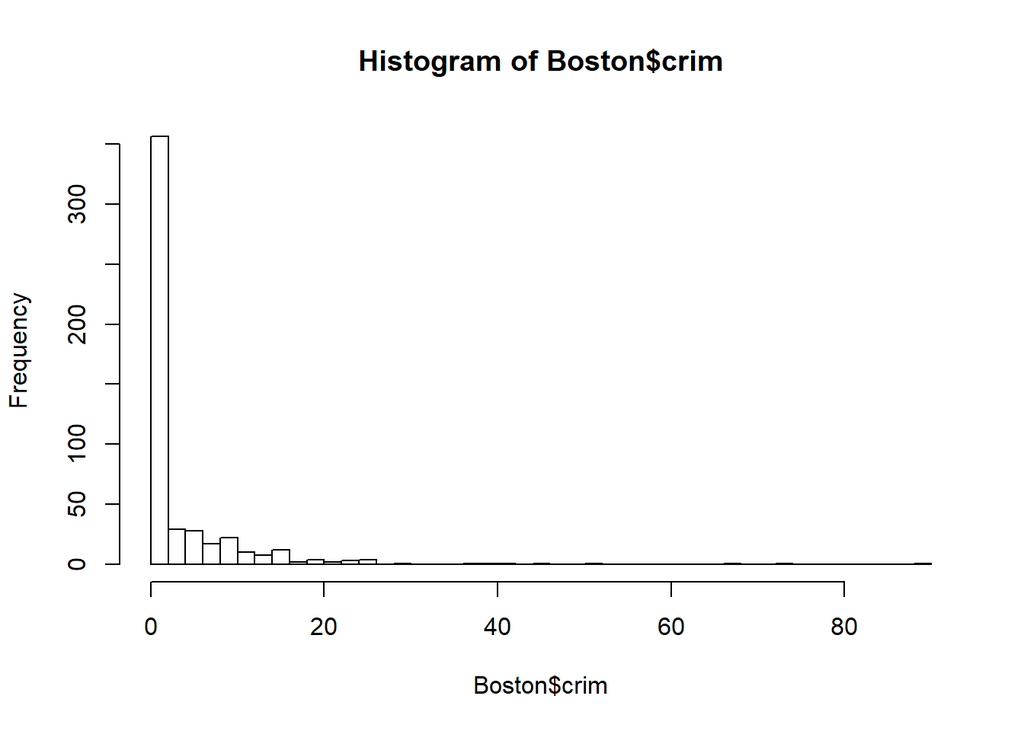

```r
hist(Boston$crim, breaks = 50)
```

```r
nrow(Boston[Boston$crim > 20, ])
```

```
## [1] 18
```

```r
range(Boston$crim)
```

```
## [1]  0.00632 88.97620
```

There are 18 suburbs appear to have a crime rate > 20. The range of crime rate is from 0.00632 to 88.97620

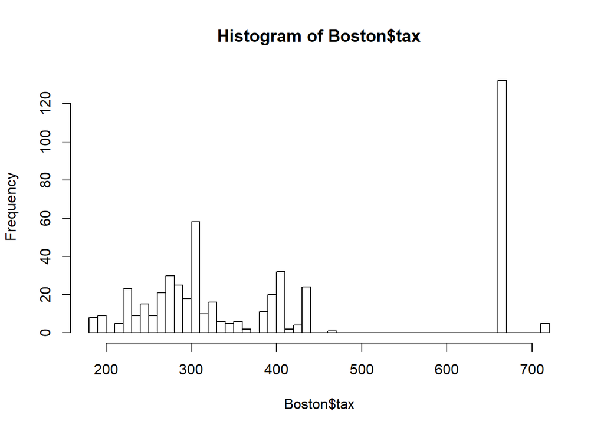

```r
hist(Boston$tax, breaks = 50)
```

```r
nrow(Boston[Boston$tax > 660, ])
```

```
## [1] 137
```

```r
range(Boston$tax)
```

```
## [1] 187 711
```

There are 137 suburbs appear to have a tax rate > 660. The range of the tax rate is from 187 to 711

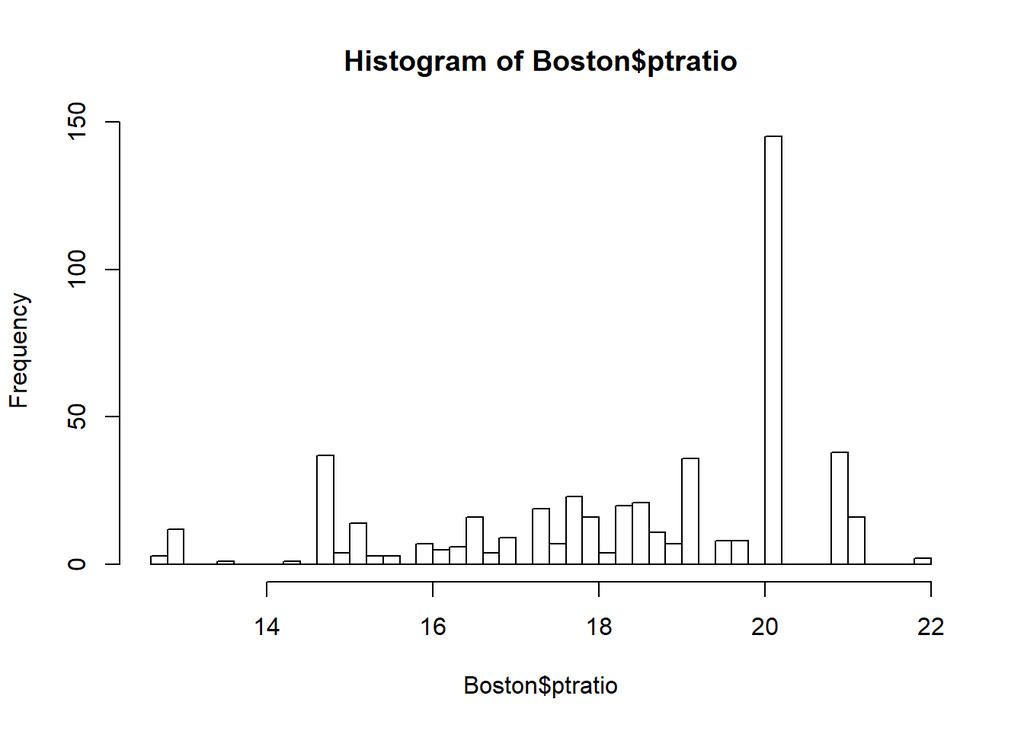

```r
hist(Boston$ptratio, breaks = 50)
```

```r
nrow(Boston[Boston$ptratio > 20, ])
```

```
## [1] 201
```

```r
range(Boston$ptratio)
```

```
## [1] 12.6 22.0
```

There are 201 suburbs appear to have Pupil-teacher ratios > 20. The range of Pupil-teacher ratios is from 12.6 to 22

#### (e)

```r
nrow(Boston[Boston$chas == 1, ])
```

```
## [1] 35
```

There are 35 suburbs in this data set bound the Charles river

#### (f)

```r
mean(Boston$ptratio)
```

```
## [1] 18.45553
```

```r
sd(Boston$ptratio)
```

```
## [1] 2.164946
```

The mean and standard deviation of the pupil-teacher ratio among the towns in this data set are 18.45553 and 2.164946

#### (g)

```r
t(subset(Boston, medv == max(Boston$medv)))
```

```
##               162       163       164       167       187       196
## crim      1.46336   1.83377   1.51902   2.01019   0.05602   0.01381
## zn        0.00000   0.00000   0.00000   0.00000   0.00000  80.00000
## indus    19.58000  19.58000  19.58000  19.58000   2.46000   0.46000
## chas      0.00000   1.00000   1.00000   0.00000   0.00000   0.00000
## nox       0.60500   0.60500   0.60500   0.60500   0.48800   0.42200
## rm        7.48900   7.80200   8.37500   7.92900   7.83100   7.87500
## age      90.80000  98.20000  93.90000  96.20000  53.60000  32.00000
## dis       1.97090   2.04070   2.16200   2.04590   3.19920   5.64840
## rad       5.00000   5.00000   5.00000   5.00000   3.00000   4.00000
## tax     403.00000 403.00000 403.00000 403.00000 193.00000 255.00000
## ptratio  14.70000  14.70000  14.70000  14.70000  17.80000  14.40000
## black   374.43000 389.61000 388.45000 369.30000 392.63000 394.23000
## lstat     1.73000   1.92000   3.32000   3.70000   4.45000   2.97000
## medv     50.00000  50.00000  50.00000  50.00000  50.00000  50.00000
##               205       226       258       268       284       369
## crim      0.02009   0.52693   0.61154   0.57834   0.01501   4.89822
## zn       95.00000   0.00000  20.00000  20.00000  90.00000   0.00000
## indus     2.68000   6.20000   3.97000   3.97000   1.21000  18.10000
## chas      0.00000   0.00000   0.00000   0.00000   1.00000   0.00000
## nox       0.41610   0.50400   0.64700   0.57500   0.40100   0.63100
## rm        8.03400   8.72500   8.70400   8.29700   7.92300   4.97000
## age      31.90000  83.00000  86.90000  67.00000  24.80000 100.00000
## dis       5.11800   2.89440   1.80100   2.42160   5.88500   1.33250
## rad       4.00000   8.00000   5.00000   5.00000   1.00000  24.00000
## tax     224.00000 307.00000 264.00000 264.00000 198.00000 666.00000
## ptratio  14.70000  17.40000  13.00000  13.00000  13.60000  20.20000
## black   390.55000 382.00000 389.70000 384.54000 395.52000 375.52000
## lstat     2.88000   4.63000   5.12000   7.44000   3.16000   3.26000
## medv     50.00000  50.00000  50.00000  50.00000  50.00000  50.00000
##               370       371      372       373
## crim      5.66998   6.53876   9.2323   8.26725
## zn        0.00000   0.00000   0.0000   0.00000
## indus    18.10000  18.10000  18.1000  18.10000
## chas      1.00000   1.00000   0.0000   1.00000
## nox       0.63100   0.63100   0.6310   0.66800
## rm        6.68300   7.01600   6.2160   5.87500
## age      96.80000  97.50000 100.0000  89.60000
## dis       1.35670   1.20240   1.1691   1.12960
## rad      24.00000  24.00000  24.0000  24.00000
## tax     666.00000 666.00000 666.0000 666.00000
## ptratio  20.20000  20.20000  20.2000  20.20000
## black   375.33000 392.05000 366.1500 347.88000
## lstat     3.73000   2.96000   9.5300   8.88000
## medv     50.00000  50.00000  50.0000  50.00000
```

The 162nd, 163rd, 164th, 167th, 187th, 196th, 205th, 226th, 258th, 268th, 284th, 369th, 370th, 371st, 372nd, 373rd suburb have highest median value of owner-occupied homes.

#### (h)

```r
nrow(Boston[Boston$rm > 6, ])
```

```
## [1] 333
```

There are 333 suburbs average more than six rooms per dwelling.

```r
nrow(Boston[Boston$rm > 8, ])
```

```
## [1] 13
```

```r
summary(subset(Boston, rm > 8))
```

```
##       crim               zn            indus             chas
##  Min.   :0.02009   Min.   : 0.00   Min.   : 2.680   Min.   :0.0000
##  1st Qu.:0.33147   1st Qu.: 0.00   1st Qu.: 3.970   1st Qu.:0.0000
##  Median :0.52014   Median : 0.00   Median : 6.200   Median :0.0000
##  Mean   :0.71879   Mean   :13.62   Mean   : 7.078   Mean   :0.1538
##  3rd Qu.:0.57834   3rd Qu.:20.00   3rd Qu.: 6.200   3rd Qu.:0.0000
##  Max.   :3.47428   Max.   :95.00   Max.   :19.580   Max.   :1.0000
##       nox               rm             age             dis
##  Min.   :0.4161   Min.   :8.034   Min.   : 8.40   Min.   :1.801
##  1st Qu.:0.5040   1st Qu.:8.247   1st Qu.:70.40   1st Qu.:2.288
##  Median :0.5070   Median :8.297   Median :78.30   Median :2.894
##  Mean   :0.5392   Mean   :8.349   Mean   :71.54   Mean   :3.430
##  3rd Qu.:0.6050   3rd Qu.:8.398   3rd Qu.:86.50   3rd Qu.:3.652
##  Max.   :0.7180   Max.   :8.780   Max.   :93.90   Max.   :8.907
##       rad              tax           ptratio          black
##  Min.   : 2.000   Min.   :224.0   Min.   :13.00   Min.   :354.6
##  1st Qu.: 5.000   1st Qu.:264.0   1st Qu.:14.70   1st Qu.:384.5
##  Median : 7.000   Median :307.0   Median :17.40   Median :386.9
##  Mean   : 7.462   Mean   :325.1   Mean   :16.36   Mean   :385.2
##  3rd Qu.: 8.000   3rd Qu.:307.0   3rd Qu.:17.40   3rd Qu.:389.7
##  Max.   :24.000   Max.   :666.0   Max.   :20.20   Max.   :396.9
##      lstat           medv
##  Min.   :2.47   Min.   :21.9
##  1st Qu.:3.32   1st Qu.:41.7
##  Median :4.14   Median :48.3
##  Mean   :4.31   Mean   :44.2
##  3rd Qu.:5.12   3rd Qu.:50.0
##  Max.   :7.44   Max.   :50.0
```

```r
summary(Boston)
```

```
##       crim                zn             indus            chas
##  Min.   : 0.00632   Min.   :  0.00   Min.   : 0.46   Min.   :0.00000
##  1st Qu.: 0.08204   1st Qu.:  0.00   1st Qu.: 5.19   1st Qu.:0.00000
##  Median : 0.25651   Median :  0.00   Median : 9.69   Median :0.00000
##  Mean   : 3.61352   Mean   : 11.36   Mean   :11.14   Mean   :0.06917
##  3rd Qu.: 3.67708   3rd Qu.: 12.50   3rd Qu.:18.10   3rd Qu.:0.00000
##  Max.   :88.97620   Max.   :100.00   Max.   :27.74   Max.   :1.00000
##       nox               rm             age              dis
##  Min.   :0.3850   Min.   :3.561   Min.   :  2.90   Min.   : 1.130
##  1st Qu.:0.4490   1st Qu.:5.886   1st Qu.: 45.02   1st Qu.: 2.100
##  Median :0.5380   Median :6.208   Median : 77.50   Median : 3.207
##  Mean   :0.5547   Mean   :6.285   Mean   : 68.57   Mean   : 3.795
##  3rd Qu.:0.6240   3rd Qu.:6.623   3rd Qu.: 94.08   3rd Qu.: 5.188
##  Max.   :0.8710   Max.   :8.780   Max.   :100.00   Max.   :12.127
##       rad              tax           ptratio          black
##  Min.   : 1.000   Min.   :187.0   Min.   :12.60   Min.   :  0.32
##  1st Qu.: 4.000   1st Qu.:279.0   1st Qu.:17.40   1st Qu.:375.38
##  Median : 5.000   Median :330.0   Median :19.05   Median :391.44
##  Mean   : 9.549   Mean   :408.2   Mean   :18.46   Mean   :356.67
##  3rd Qu.:24.000   3rd Qu.:666.0   3rd Qu.:20.20   3rd Qu.:396.23
##  Max.   :24.000   Max.   :711.0   Max.   :22.00   Max.   :396.90
##      lstat            medv
##  Min.   : 1.73   Min.   : 5.00
##  1st Qu.: 6.95   1st Qu.:17.02
##  Median :11.36   Median :21.20
##  Mean   :12.65   Mean   :22.53
##  3rd Qu.:16.95   3rd Qu.:25.00
##  Max.   :37.97   Max.   :50.00
```

These suburbs have relative low rate of crime and relative low status of the population comparing to the total.